# wxgenR - GHCN CONUS evaluation - in sample

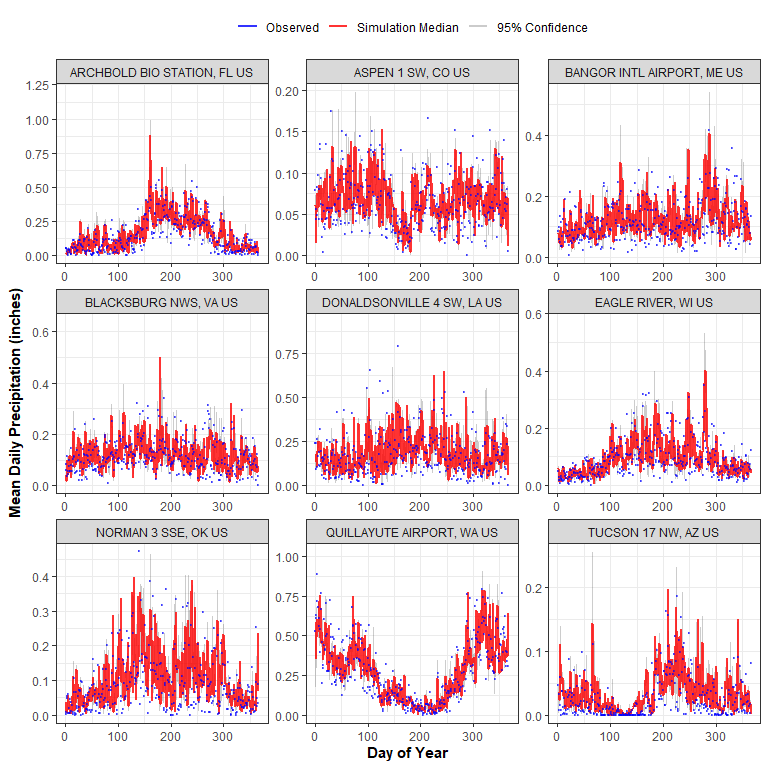

```r
# lgdLoc = c(0.8, 0.9)

if(Tag == "Temp"){
  yLabel = "Daily Temperature "
  units = "(°F)"
} else if(Tag == "Precip"){
  yLabel = "Daily Precipitation "
  units = "(inches)"
}

trnAlpha = 0.5

#daily mean
p1 = ggplot(df.daily.pcp) +
  geom_ribbon(aes(x = yday, ymin = mean_q5, ymax = mean_q95), alpha = 0.25) +
  geom_line(aes(x = yday, y = mean_med, color = "red"), size = 1, alpha = 0.8) +
  # geom_line(aes(x = yday, y = obs_mean), size = 0.15, alpha = trnAlpha-0.15, linetype = "solid", color = "blue") +
  geom_point(aes(x = yday, y = obs_mean), size = 0.3, alpha = trnAlpha, color = "blue") +
  scale_colour_manual(values =c('blue'='blue','red'='red', 'grey' = 'grey'), labels = c('Observed','Simulation Median', '95% Confidence')) +
  theme_bw() +
  theme(axis.title = element_text(face = "bold"),
        # text=element_text(size=14),
        panel.grid.major = element_line(),
        legend.title=element_blank(),
        legend.position = "top",
        legend.background = element_blank(),
        legend.box.background = element_blank(),
        legend.key = element_blank()) +
  xlab("Day of Year") + ylab(paste0("Mean ", yLabel, units)) +
  facet_wrap(~Name, scales = "free")

print(p1)
```

```r
# p.out = paste0(outDirPlots, "/dailyStats_faceted_precipitation.png")
# ggsave(filename = p.out, plot = p1, device = "png", height = 8, width = 8, units = "in")
```

### plot temp

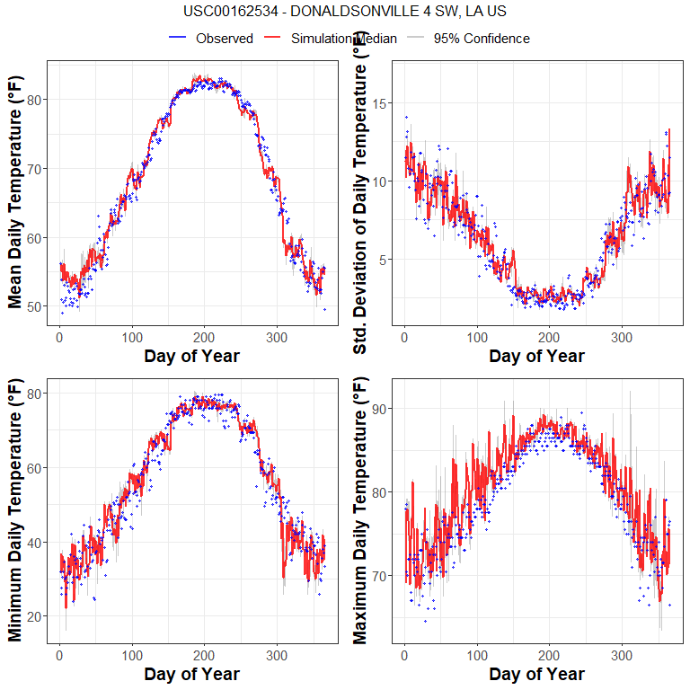

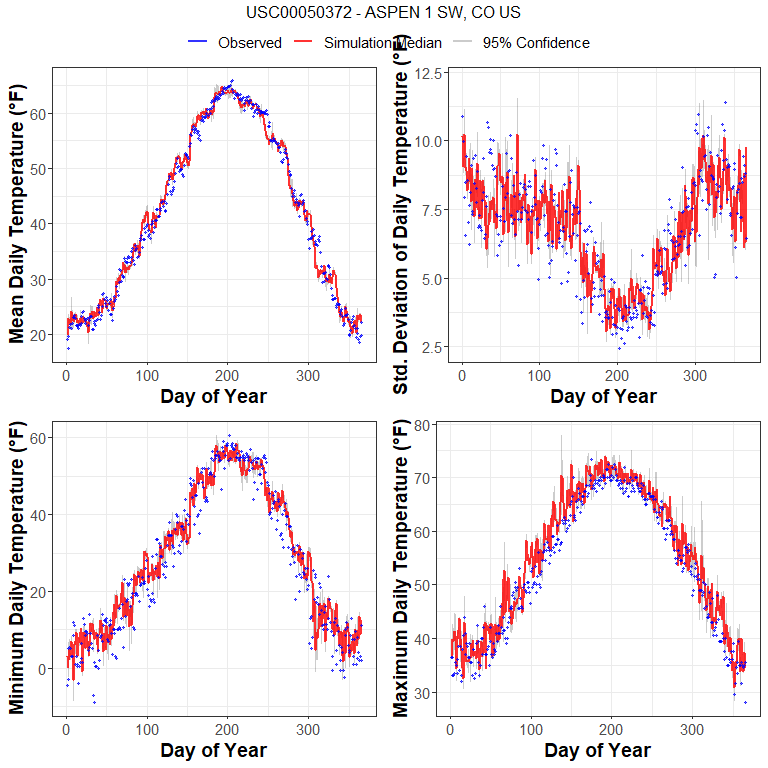

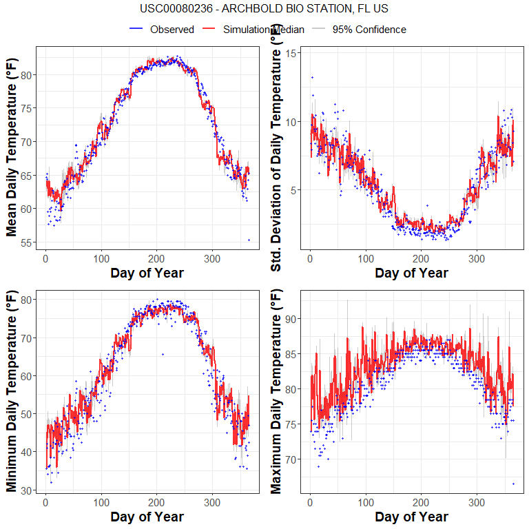

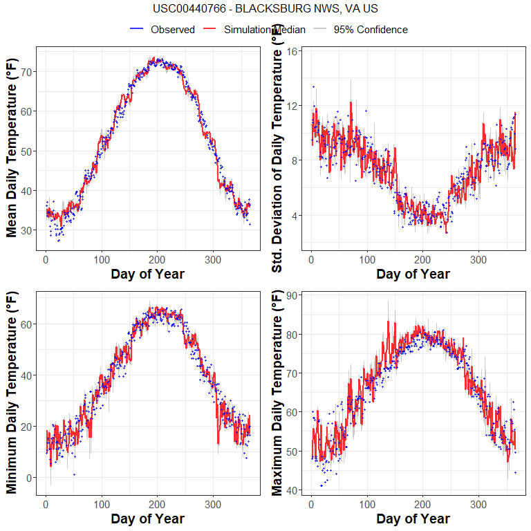

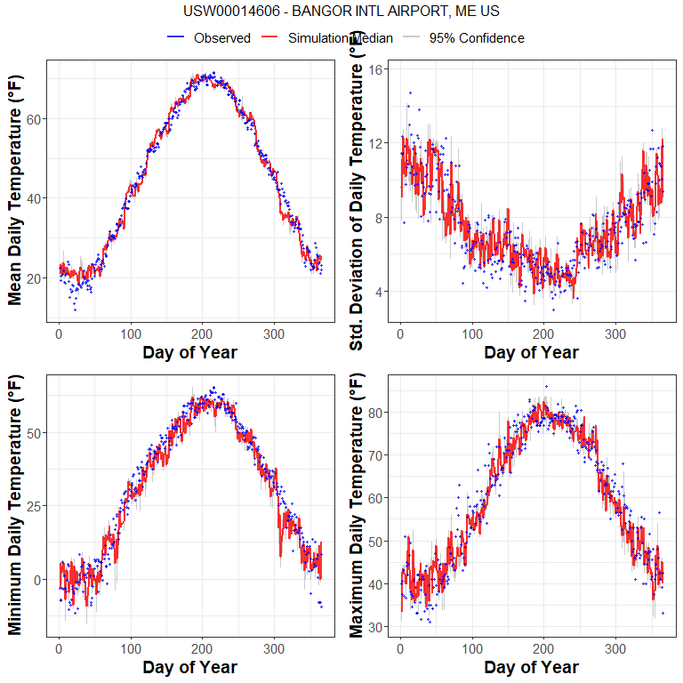

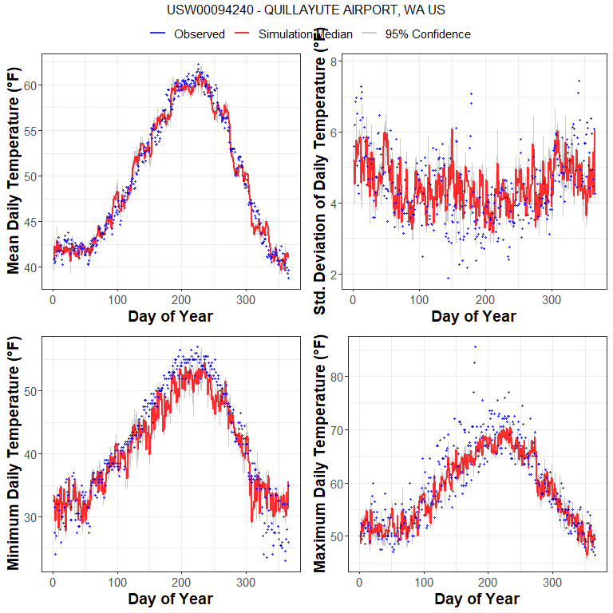

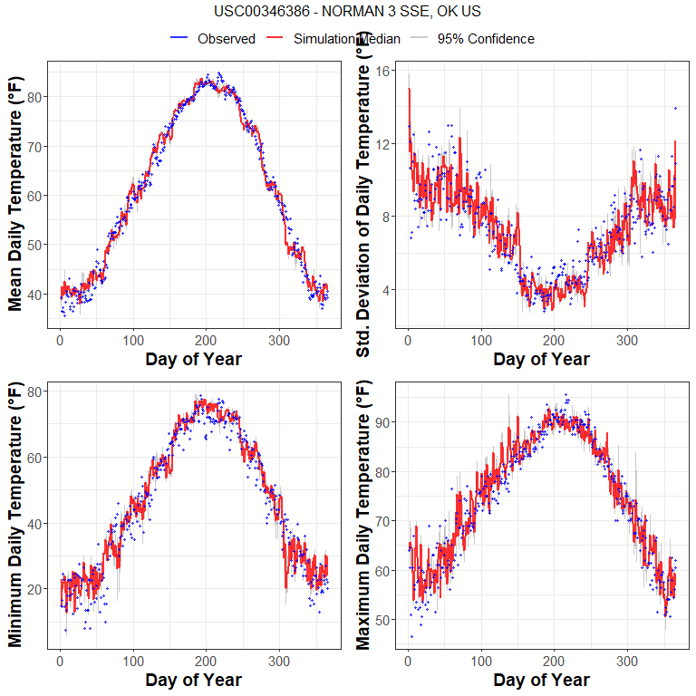

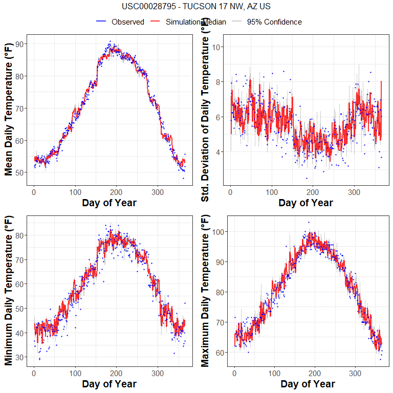

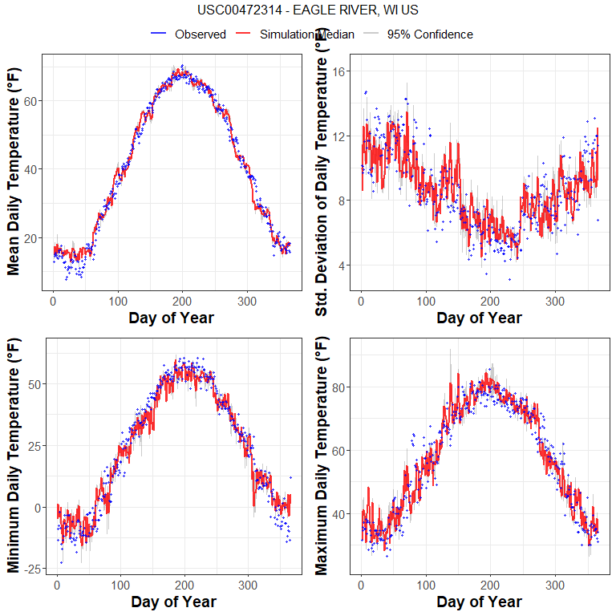

```r
df.daily.tmp = NULL
df.daily.tmp.perf = NULL

for(i in 1:n){

  simDat = datListProc[[i]][[1]]$sim.tmp
  obsDat = datListProc[[i]][[1]]$obs.tmp
  Tag = "Temp"
  ID = datListProc[[i]][[2]]
  Name = datListProc[[i]][[3]]

  df.i = dailyPlot(simDat, obsDat, Tag, ID, Name)

  df.daily.tmp = rbind(df.daily.tmp, df.i[[1]])
  df.daily.tmp.perf = rbind(df.daily.tmp.perf, df.i[[2]])

}
```

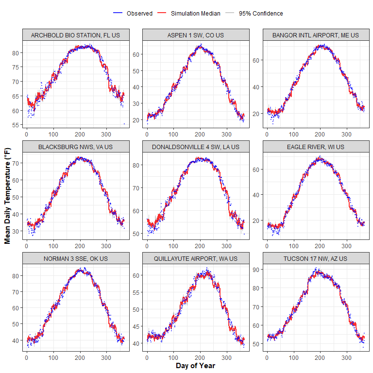

```r
# lgdLoc = c(0.8, 0.9)

if(Tag == "Temp"){
  yLabel = "Daily Temperature "
  units = "(°F)"
} else if(Tag == "Precip"){
  yLabel = "Daily Precipitation "
  units = "(inches)"
}

trnAlpha = 0.5

#daily mean
p1 = ggplot(df.daily.tmp) +
  geom_ribbon(aes(x = yday, ymin = mean_q5, ymax = mean_q95), alpha = 0.25) +
  geom_line(aes(x = yday, y = mean_med, color = "red"), size = 1, alpha = 0.8) +
  # geom_line(aes(x = yday, y = obs_mean), size = 0.15, alpha = trnAlpha-0.15, linetype = "solid", color = "blue") +
  geom_point(aes(x = yday, y = obs_mean), size = 0.3, alpha = trnAlpha, color = "blue") +
  scale_colour_manual(values =c('blue'='blue','red'='red', 'grey' = 'grey'), labels = c('Observed','Simulation Median', '95% Confidence')) +
  theme_bw() +
  theme(axis.title = element_text(face = "bold"),
        # text=element_text(size=14),
        panel.grid.major = element_line(),
        legend.title=element_blank(),
        legend.position = "top",
        legend.background = element_blank(),
        legend.box.background = element_blank(),
        legend.key = element_blank()) +
  xlab("Day of Year") + ylab(paste0("Mean ", yLabel, units)) +
  facet_wrap(~Name, scales = "free")

print(p1)
```

```r
# p.out = paste0(outDirPlots, "/dailyStats_faceted_temperature.png")
# ggsave(filename = p.out, plot = p1, device = "png", height = 8, width = 8, units = "in")
```

```r
perfComb = rbind(df.daily.pcp.perf, df.daily.tmp.perf)

# write.csv(perfComb, paste0(outDir, "/stations_dailyPerfMetrics.csv"), row.names = F)
```

### We can also calculate dry- and wet- spell length statistics for further verification.

```r
i = 1
x = subset(datListProc[[i]][[1]]$sim.pcp, variable == "Trace_1")$value
month = subset(datListProc[[i]][[1]]$sim.pcp, variable == "Trace_1")$month

spells = function(x, month){

  df = data.frame(x, month)
  df$Flag = NA
  n = nrow(df)

  #flags (1 = day i pcp is below threshold (0.01 inch), 0 = above threshold)
  i = 1
  for(i in 1:n){

    if(df$x[i] < 0.01){
    df$Flag[i] = 1
    } else{
    df$Flag[i] = 0
    }

  }

  #spell durations ------------

  #add dummy 0 at end of data
  df[nrow(df)+1,] = NA
  df$x[nrow(df)] = 0
  df$Flag[nrow(df)] = 0
  # tail(df$value, 1) = 0

  #dry spells -----
  duration.dry = c()
  # s.m = c()
  e.m.dry = c()

  d.i = 0

  i = 1
  for(i in 1:n){

    #if year i and year i + 1 flows are both below threshold, increment duration for spell
    if(df$Flag[i] == 1 & df$Flag[i+1] == 1){

    d.i = d.i + 1

    #if year i is below threshold, but year i + 1 is not, that is the end of the dry spell, finish incrementing and save values, then reset for calculation of the next spell's stats
    } else if(df$Flag[i] == 1 & df$Flag[i+1] == 0){

    d.i = d.i + 1

    e.m.dry = c(e.m.dry, df$month[i])
    duration.dry = c(duration.dry, d.i)

    d.i = 0

    }

  }

  out.dry = data.frame(duration = duration.dry, month = e.m.dry)

  #wet spells -----
  duration.wet = c()
  # s.m = c()
  e.m.wet = c()

  w.i = 0

  i = 1
  for(i in 1:n){

    #if year i and year i + 1 flows are both above threshold, increment duration for spell
    if(df$Flag[i] == 0 & df$Flag[i+1] == 0){

    w.i = w.i + 1

    #if year i is above threshold, but year i + 1 is not, that is the end of the wet spell, finish incrementing and save values, then reset for calculation of the next spell's stats
    } else if(df$Flag[i] == 0 & df$Flag[i+1] == 1){

    w.i = w.i + 1

    e.m.wet = c(e.m.wet, df$month[i])
    duration.wet = c(duration.wet, w.i)

    w.i = 0

    }

  }

  out.wet = data.frame(duration = duration.wet, month = e.m.wet)

  return(list(dry = out.dry, wet = out.wet))
}
```

```r
df.daily.spells = NULL

i = 1
for(i in 1:n){

  simDat = datListProc[[i]][[1]]$sim.pcp
  obsDat = datListProc[[i]][[1]]$obs.pcp
  ID = datListProc[[i]][[2]]
  Name = datListProc[[i]][[3]]

  j = 1
  for(j in 1:nrealz){

    trace.j = paste0("Trace_", j)

    df.j = subset(simDat, variable == trace.j)

    spells.j = spells(x = df.j$value, month = df.j$month)

    df.spells.dry = spells.j$dry %>%
      group_by(month) %>%
      summarise(mean = mean(duration, na.rm = T),
                sd = sd(duration, na.rm = T),
                max = max(duration, na.rm = T)
                ) %>%
      mutate(Tag = "Dry Spells", ID = ID, Name = Name, Type = "Simulated", Trace = trace.j)

    df.spells.wet = spells.j$wet %>%
      group_by(month) %>%
      summarise(mean = mean(duration, na.rm = T),
                sd = sd(duration, na.rm = T),
                max = max(duration, na.rm = T)
                ) %>%
      mutate(Tag = "Wet Spells", ID = ID, Name = Name, Type = "Simulated", Trace = trace.j)

    df.daily.spells = rbind(df.daily.spells, df.spells.dry, df.spells.wet)

  }

  spells.o = spells(x = obsDat$prcp, month = obsDat$month)

  df.spells.dry.o = spells.o$dry %>%
    subset(duration <= 365) %>%
    group_by(month) %>%
    summarise(mean = mean(duration, na.rm = T),
              sd = sd(duration, na.rm = T),
              max = max(duration, na.rm = T)
              ) %>%
    mutate(Tag = "Dry Spells", ID = ID, Name = Name, Type = "Observed", Trace = "Observed")

  df.spells.wet.o = spells.o$wet %>%
    subset(duration <= 365) %>%
    group_by(month) %>%
    summarise(mean = mean(duration, na.rm = T),
              sd = sd(duration, na.rm = T),
              max = max(duration, na.rm = T)
              ) %>%
    mutate(Tag = "Wet Spells", ID = ID, Name = Name, Type = "Observed", Trace = "Observed")

  df.daily.spells = rbind(df.daily.spells, df.spells.dry.o, df.spells.wet.o)

}
```

```r
df.daily.spells = as.data.frame(df.daily.spells)
# colnames(df.daily.spells)[4] = "Type"
#
# df.daily.spells[,6:8] = apply(df.daily.spells[,6:8], 2, as.numeric)
```

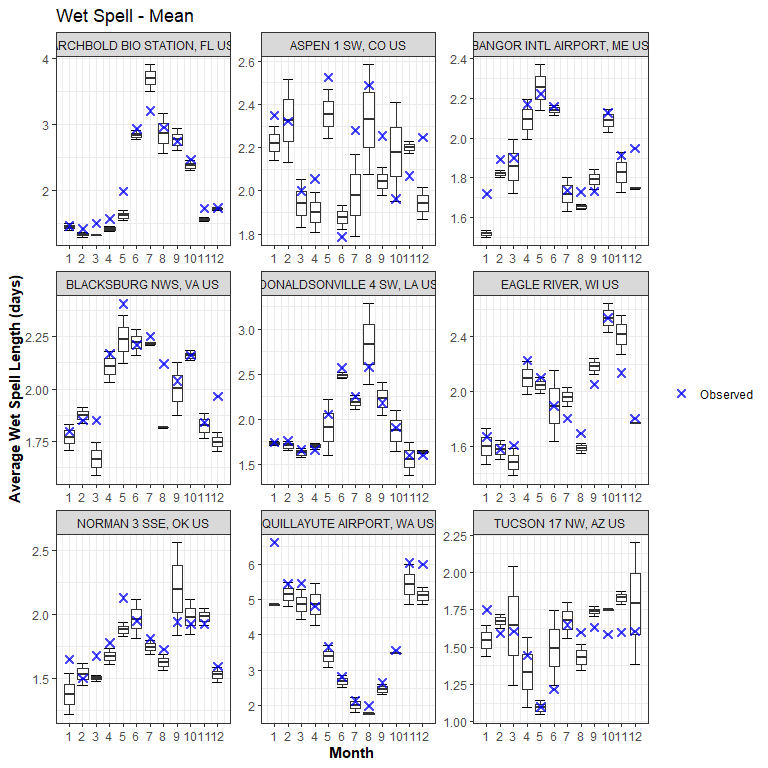

```r
#daily mean - wet
p1 = ggplot(data = subset(df.daily.spells,
                          Type == "Simulated" & Tag == "Wet Spells"),
            aes(x = month, y = mean, group = month)) +
  stat_boxplot(geom = "errorbar") +
  geom_boxplot() +
  facet_wrap(~Name, scales = "free") +
  scale_colour_manual(values=c('blue'='blue'), labels = c('Observed')) +
  theme_bw() +
  theme(axis.title = element_text(face = "bold"),
        # text=element_text(size=14),
        panel.grid.major = element_line(),
        legend.title=element_blank(),
        legend.position = "right",
        legend.background = element_blank(),
        legend.box.background = element_blank(),
        ) +
  xlab("Month") +
  ylab("Average Wet Spell Length (days)") +
  labs(title = "Wet Spell - Mean") +
  scale_x_continuous(labels = 1:12, breaks = 1:12)

p1 = p1 + geom_point(data = subset(df.daily.spells,
                                   Type == "Observed" & Tag == "Wet Spells"),
                     aes(x = month, y = mean, group = month),
                     color = "blue", alpha = 0.7,
                     shape = 4, size = 2, stroke = 1.5,
                     show.legend = T)


print(p1)
```

```r
# p.out = paste0(outDirPlots, "/meanWetSpellLengths.png")
# ggsave(filename = p.out, plot = p1, device = "png", height = 8, width = 8, units = "in")
```

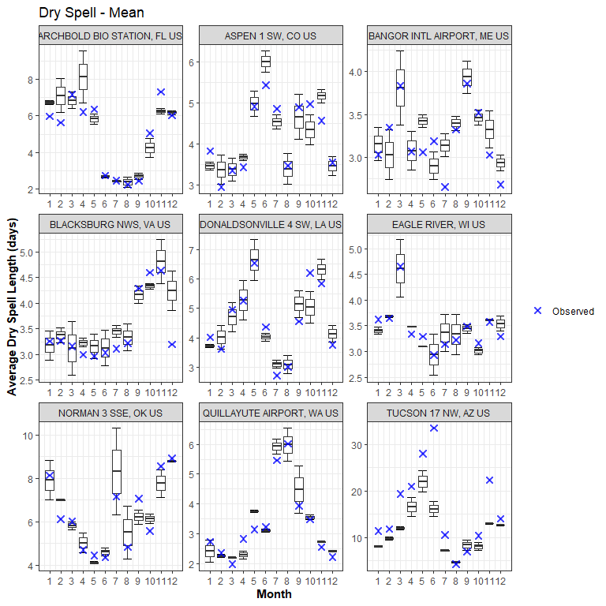

```r
#daily mean - dry
p1 = ggplot(data = subset(df.daily.spells,
                          Type == "Simulated" & Tag == "Dry Spells"),
            aes(x = month, y = mean, group = month)) +
  stat_boxplot(geom = "errorbar") +
  geom_boxplot() +
  facet_wrap(~Name, scales = "free") +
  scale_colour_manual(values=c('blue'='blue'), labels = c('Observed')) +
  theme_bw() +
  theme(axis.title = element_text(face = "bold"),
        # text=element_text(size=14),
        panel.grid.major = element_line(),
        legend.title=element_blank(),
        legend.position = "right",
        legend.background = element_blank(),
        legend.box.background = element_blank(),
        ) +
  xlab("Month") +
  ylab("Average Dry Spell Length (days)") +
  labs(title = "Dry Spell - Mean") +
  scale_x_continuous(labels = 1:12, breaks = 1:12)

p1 = p1 + geom_point(data = subset(df.daily.spells,
                                   Type == "Observed" & Tag == "Dry Spells"),
                     aes(x = month, y = mean, group = month),
                     color = "blue", alpha = 0.7,
                     shape = 4, size = 2, stroke = 1.5,
                     show.legend = T)


print(p1)
```

```r
# p.out = paste0(outDirPlots, "/meanDrySpellLengths.png")
# ggsave(filename = p.out, plot = p1, device = "png", height = 8, width = 8, units = "in")
```

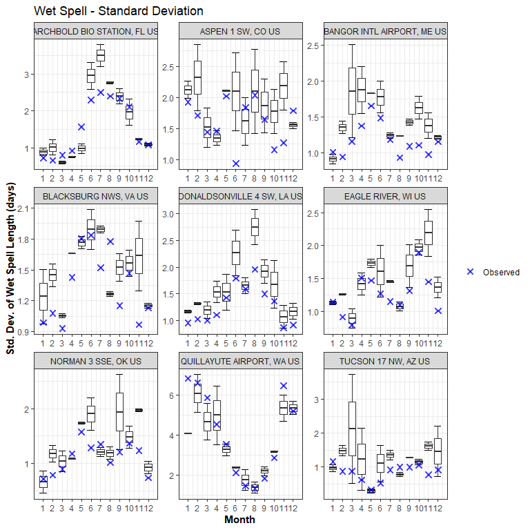

```r
#daily sd - wet
p1 = ggplot(data = subset(df.daily.spells,
                          Type == "Simulated" & Tag == "Wet Spells"),
            aes(x = month, y = sd, group = month)) +
  stat_boxplot(geom = "errorbar") +
  geom_boxplot() +
  facet_wrap(~Name, scales = "free") +
  scale_colour_manual(values=c('blue'='blue'), labels = c('Observed')) +
  theme_bw() +
  theme(axis.title = element_text(face = "bold"),
        # text=element_text(size=14),
        panel.grid.major = element_line(),
        legend.title=element_blank(),
        legend.position = "right",
        legend.background = element_blank(),
        legend.box.background = element_blank(),
        ) +
  xlab("Month") +
  ylab("Std. Dev. of Wet Spell Length (days)") +
  labs(title = "Wet Spell - Standard Deviation") +
  scale_x_continuous(labels = 1:12, breaks = 1:12)

p1 = p1 + geom_point(data = subset(df.daily.spells,
                                   Type == "Observed" & Tag == "Wet Spells"),
                     aes(x = month, y = sd, group = month),
                     color = "blue", alpha = 0.7,
                     shape = 4, size = 2, stroke = 1.5,
                     show.legend = T)


print(p1)
```

```r
# p.out = paste0(outDirPlots, "/sdWetSpellLengths.png")
# ggsave(filename = p.out, plot = p1, device = "png", height = 8, width = 8, units = "in")
```

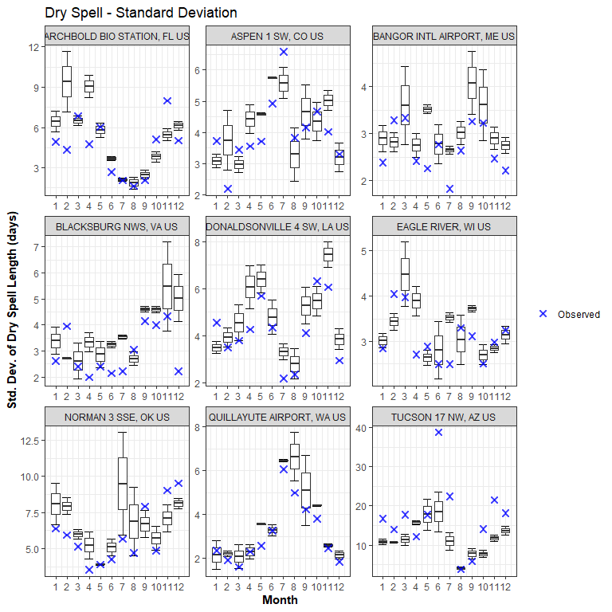

```r
#daily sd
p1 = ggplot(data = subset(df.daily.spells,
                          Type == "Simulated" & Tag == "Dry Spells"),
            aes(x = month, y = sd, group = month)) +
  stat_boxplot(geom = "errorbar") +
  geom_boxplot() +
  facet_wrap(~Name, scales = "free") +
  scale_colour_manual(values=c('blue'='blue'), labels = c('Observed')) +
  theme_bw() +
  theme(axis.title = element_text(face = "bold"),
        # text=element_text(size=14),
        panel.grid.major = element_line(),
        legend.title=element_blank(),
        legend.position = "right",
        legend.background = element_blank(),
        legend.box.background = element_blank(),
        ) +
  xlab("Month") +
  ylab("Std. Dev. of Dry Spell Length (days)") +
  labs(title = "Dry Spell - Standard Deviation") +
  scale_x_continuous(labels = 1:12, breaks = 1:12)

p1 = p1 + geom_point(data = subset(df.daily.spells,
                                   Type == "Observed" & Tag == "Dry Spells"),
                     aes(x = month, y = sd, group = month),
                     color = "blue", alpha = 0.7,
                     shape = 4, size = 2, stroke = 1.5,
                     show.legend = T)


print(p1)
```

```r
# p.out = paste0(outDirPlots, "/sdDrySpellLengths.png")
# ggsave(filename = p.out, plot = p1, device = "png", height = 8, width = 8, units = "in")
```

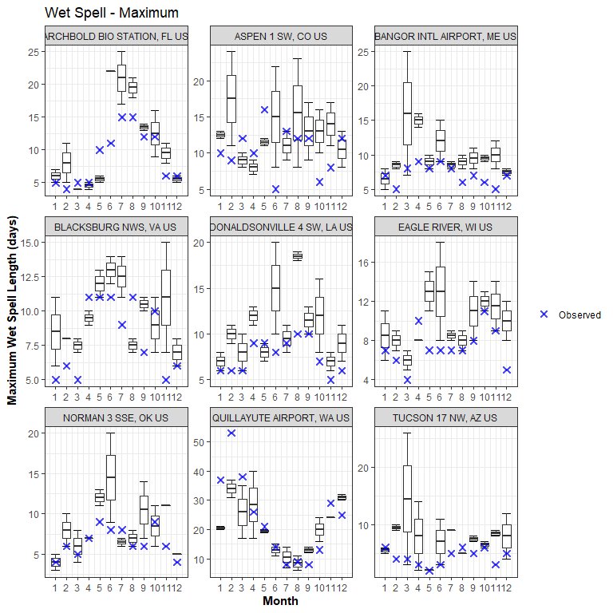

```r
#daily max - wet
p1 = ggplot(data = subset(df.daily.spells,
                          Type == "Simulated" & Tag == "Wet Spells"),
            aes(x = month, y = max, group = month)) +
  stat_boxplot(geom = "errorbar") +
  geom_boxplot() +
  facet_wrap(~Name, scales = "free") +
  scale_colour_manual(values=c('blue'='blue'), labels = c('Observed')) +
  theme_bw() +
  theme(axis.title = element_text(face = "bold"),
        # text=element_text(size=14),
        panel.grid.major = element_line(),
        legend.title=element_blank(),
        legend.position = "right",
        legend.background = element_blank(),
        legend.box.background = element_blank(),
        ) +
  xlab("Month") +
  ylab("Maximum Wet Spell Length (days)") +
  labs(title = "Wet Spell - Maximum") +
  scale_x_continuous(labels = 1:12, breaks = 1:12)

p1 = p1 + geom_point(data = subset(df.daily.spells,
                                   Type == "Observed" & Tag == "Wet Spells"),
                     aes(x = month, y = max, group = month),
                     color = "blue", alpha = 0.7,
                     shape = 4, size = 2, stroke = 1.5,
                     show.legend = T)


print(p1)
```

```r
# p.out = paste0(outDirPlots, "/maxWetSpellLengths.png")
# ggsave(filename = p.out, plot = p1, device = "png", height = 8, width = 8, units = "in")
```

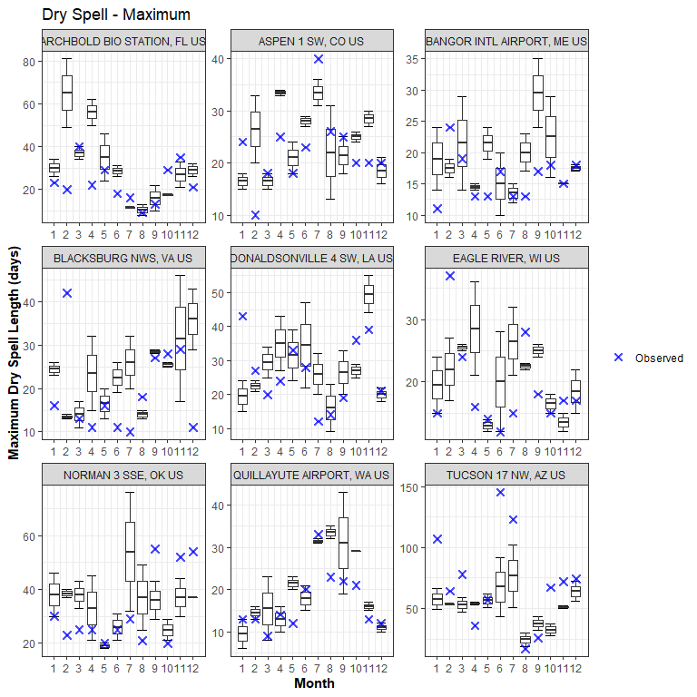

```r
#daily sd
p1 = ggplot(data = subset(df.daily.spells,
                          Type == "Simulated" & Tag == "Dry Spells"),
            aes(x = month, y = max, group = month)) +
  stat_boxplot(geom = "errorbar") +
  geom_boxplot() +
  facet_wrap(~Name, scales = "free") +
  scale_colour_manual(values=c('blue'='blue'), labels = c('Observed')) +
  theme_bw() +
  theme(axis.title = element_text(face = "bold"),
        # text=element_text(size=14),
        panel.grid.major = element_line(),
        legend.title=element_blank(),
        legend.position = "right",
        legend.background = element_blank(),
        legend.box.background = element_blank(),
        ) +
  xlab("Month") +
  ylab("Maximum Dry Spell Length (days)") +
  labs(title = "Dry Spell - Maximum") +
  scale_x_continuous(labels = 1:12, breaks = 1:12)

p1 = p1 + geom_point(data = subset(df.daily.spells,
                                   Type == "Observed" & Tag == "Dry Spells"),
                     aes(x = month, y = max, group = month),
                     color = "blue", alpha = 0.7,
                     shape = 4, size = 2, stroke = 1.5,
                     show.legend = T)


print(p1)
```

```r
# p.out = paste0(outDirPlots, "/maxDrySpellLengths.png")
# ggsave(filename = p.out, plot = p1, device = "png", height = 8, width = 8, units = "in")
```

## Final notes

- The weather simulations use a 366-day per year framework in order to handle leap years. During leap years, all 366 days will have precipitation and temperature values (i.e., February 29th exists and contains data), but during non-leap years February 29th does not exist and a row of NULL values is added after December 31st in order to maintain the same length between leap years and non-leap years. Other datasets and algorithms use various approaches to handle leap years, such as avoiding leap years altogether, using a 360-day year, etc.
- Because leap years are acceptable in the `wxgenR` algorithm, it is possible (but unlikely) to have two or more leap years in a row in the weather simulations since years are sampled at random.
- Please report any bugs or issues to either sgangopadhyay@usbr.gov or dwoodson@usbr.gov

## Citations

For more details and examples, including analysis of the dataset used in this vignette, see the following works:

```
Bearup, L., Gangopadhyay, S., & Mikkelson, K. (2021). Hydroclimate Analysis Lower Santa Cruz River Basin Study (Technical Memorandum No ENV-2020-056). Bureau of Reclamation. <https://www.usbr.gov/lc/phoenix/programs/lscrbasin/LSCRBStudy.html>

Gangopadhyay, S., Bearup, L. A., Verdin, A., Pruitt, T., Halper, E., & Shamir, E. (2019, December 1). A collaborative stochastic weather generator for climate impacts assessment in the Lower Santa Cruz River Basin, Arizona. Fall Meeting 2019, American Geophysical Union. <https://ui.adsabs.harvard.edu/abs/2019AGUFMGC41G1267G>

Rajagopalan, B., Lall, U., and Tarboton, D. G.: Nonhomogeneous Markov Model for Daily Precipitation, Journal of Hydrologic Engineering, 1, 33–40, <https://doi.org/10.1061/(ASCE)1084-0699(1996)1:1(33)>, 1996.

Verdin, A., Rajagopalan, B., Kleiber, W., and Katz, R. W.: Coupled stochastic weather generation using spatial and generalized linear models, Stoch Environ Res Risk Assess, 29, 347–356, <https://doi.org/10.1007/s00477-014-0911-6>, 2015.

Verdin, A., Rajagopalan, B., Kleiber, W., Podestá, G., and Bert, F.: A conditional stochastic weather generator for seasonal to multi-decadal simulations, Journal of Hydrology, 556, 835–846, <https://doi.org/10.1016/j.jhydrol.2015.12.036>, 2018.
```